# Data Visualization Assignment

Amy’s data visualizationassignment for PNB3EE3

# Loading in data

## Installing required packages

```r
list.of.packages <- c("tidyverse", "ggpubr", "ez", "corrplot", "car", "stats","PerformanceAnalytics", "afex", "emmeans", "mlma", "ggplot2", "ggExtra", "psych", "ggpubr", "here", "gridExtra", "ggridges","hrbrthemes","psych","ggpmisc")
```

```r
new.packages <- list.of.packages[!(list.of.packages %in% installed.packages()[,"Package"])]
if(length(new.packages)) install.packages(new.packages)
library(psych)
library(ggplot2)
```

```r
library(hrbrthemes)
```

```r
library(ggpmisc)
```

## Loading in csv file

Loading in csv file Load in csv file from https://perception-lab-pnb3ee3.github.io/courseBook/assignment_dataVis.html

```r
here::i_am("dataVisualisation_analyses.Rmd")
```

```r
library(here)
```

```r
data <- read.csv(here("assignment_dataVis_dataset.csv"))
op = 0 # saves plot inline (0) instead of in a file (1)
```

# Summary Statistics

*Preliminary inspection of the file and properties of the data*

```r
print(summary(data))
```

```
  condition               x               y
 Length:568         Min.   :19.29   Min.   : 2.949
 Class :character   1st Qu.:41.67   1st Qu.:24.095
 Mode  :character   Median :54.38   Median :46.354
                    Mean   :54.27   Mean   :47.834
                    3rd Qu.:65.02   3rd Qu.:69.199
                    Max.   :98.21   Max.   :99.580
```

```r
head(data)
```

|  | condition | x | y |
| --- | --- | --- | --- |
| 1 | condition_1 | 55.3846 | 97.1795 |
| 2 | condition_1 | 51.5385 | 96.0256 |
| 3 | condition_1 | 46.1538 | 94.4872 |
| 4 | condition_1 | 42.8205 | 91.4103 |
| 5 | condition_1 | 40.7692 | 88.3333 |
| 6 | condition_1 | 38.7179 | 84.8718 |

## *Sorting data by conditions*

```r
df_list <- split(data, data$condition)

df_condition1 <- df_list[["condition_1"]]
df_condition2 <- df_list[["condition_2"]]
df_condition3 <- df_list[["condition_3"]]
df_condition4 <- df_list[["condition_4"]]
```

## Condition 1 statistics

```r
describe(df_condition1)
```

|  | vars | n | mean | sd | median | trimmed | mad | min | max | range | skew | kurtosis | se |
| --- | --- | --- | --- | --- | --- | --- | --- | --- | --- | --- | --- | --- | --- |
| condition* | 1 | 142 | 1.00 | 0.00 | 1.00 | 1.00 | 0.00 | 1.00 | 1.00 | 0.00 | NaN | NaN | 0.00 |
| x | 2 | 142 | 54.26 | 16.77 | 53.33 | 53.69 | 15.97 | 22.31 | 98.21 | 75.90 | 0.28 | -0.29 | 1.41 |
| y | 3 | 142 | 47.83 | 26.94 | 46.03 | 46.90 | 30.79 | 2.95 | 99.49 | 96.54 | 0.25 | -1.06 | 2.26 |

## Condition 2 statistics

```r
describe(df_condition2)
```

|  | vars | n | mean | sd | median | trimmed | mad | min | max | range | skew | kurtosis | se |
| --- | --- | --- | --- | --- | --- | --- | --- | --- | --- | --- | --- | --- | --- |
| condition* | 1 | 142 | 1.00 | 0.00 | 1.00 | 1.00 | 0.00 | 1.00 | 1.00 | 0.00 | NaN | NaN | 0.00 |
| x | 2 | 142 | 54.27 | 16.77 | 53.84 | 53.86 | 17.49 | 19.29 | 91.74 | 72.45 | 0.17 | -0.27 | 1.41 |
| y | 3 | 142 | 47.83 | 26.94 | 47.38 | 47.83 | 36.83 | 9.69 | 85.88 | 76.18 | 0.01 | -1.45 | 2.26 |

## Condition 3 statistics

```r
describe(df_condition3)
```

|  | vars | n | mean | sd | median | trimmed | mad | min | max | range | skew | kurtosis | se |
| --- | --- | --- | --- | --- | --- | --- | --- | --- | --- | --- | --- | --- | --- |
| condition* | 1 | 142 | 1.00 | 0.00 | 1.00 | 1.00 | 0.00 | 1.00 | 1.00 | 0.00 | NaN | NaN | 0.00 |
| x | 2 | 142 | 54.27 | 16.77 | 54.26 | 53.69 | 16.13 | 20.21 | 95.26 | 75.05 | 0.23 | -0.38 | 1.41 |
| y | 3 | 142 | 47.83 | 26.94 | 45.29 | 46.83 | 33.80 | 5.65 | 99.58 | 93.93 | 0.26 | -1.09 | 2.26 |

## Condition 4 statistics

```r
describe(df_condition4)
```

|  | vars | n | mean | sd | median | trimmed | mad | min | max | range | skew | kurtosis | se |
| --- | --- | --- | --- | --- | --- | --- | --- | --- | --- | --- | --- | --- | --- |
| condition* | 1 | 142 | 1.00 | 0.00 | 1.00 | 1.00 | 0.00 | 1.00 | 1.00 | 0.00 | NaN | NaN | 0.00 |
| x | 2 | 142 | 54.27 | 16.77 | 56.53 | 54.33 | 22.16 | 27.02 | 86.44 | 59.41 | 0.08 | -1.19 | 1.41 |
| y | 3 | 142 | 47.84 | 26.93 | 50.11 | 46.56 | 37.30 | 14.37 | 92.21 | 77.85 | 0.24 | -1.36 | 2.26 |

# Data Visualization

## Condition 1

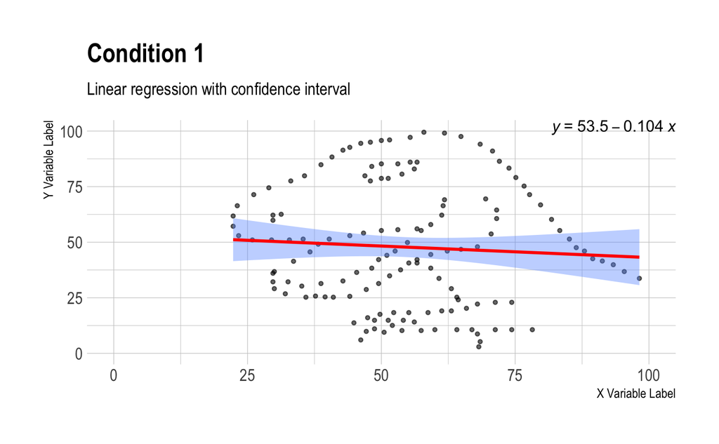

```r
condition1_plot <- ggplot(df_condition1, aes(x=x, y=y)) +
  geom_point(size=1, alpha=0.6) +
  geom_smooth(method=lm , color="red", fill="#6699ff", se=TRUE) +
    stat_poly_eq(aes(label = ..eq.label..),
    formula = y ~ x,
    label.x = max(df_condition1$x) * 0.5,  # Position near the right
    label.y = max(df_condition1$y) * 0.9   # Position near the top
  )+
  theme_ipsum() +
   labs(
    title = "Condition 1",
    subtitle = "Linear regression with confidence interval",
    x = "X Variable Label",
    y = "Y Variable Label"
    )+
  xlim(0,100)+ylim(0,100)
condition1_plot
```

## Condition 2

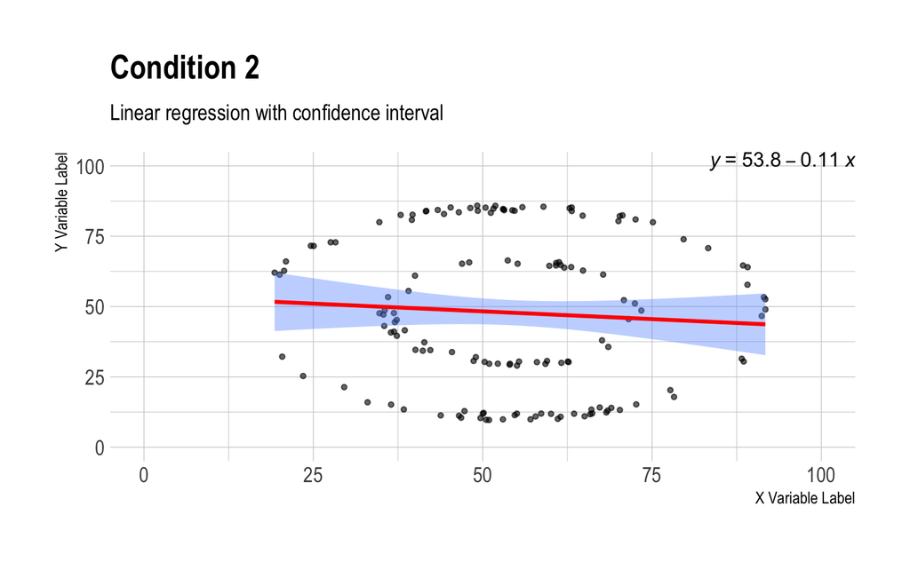

```r
condition2_plot <- ggplot(df_condition2, aes(x=x, y=y)) +
  geom_point(size=1, alpha=0.6) +
  geom_smooth(method=lm , color="red", fill="#6699ff", se=TRUE) +
    stat_poly_eq(aes(label = ..eq.label..),
    formula = y ~ x,
    label.x = max(df_condition2$x) * 0.5,
    label.y = max(df_condition2$y) * 0.9
  )+
  theme_ipsum() +
   labs(
    title = "Condition 2",
    subtitle = "Linear regression with confidence interval",
    x = "X Variable Label",
    y = "Y Variable Label"
    )+
  xlim(0,100)+ylim(0,100)
condition2_plot
```

## Condition 3

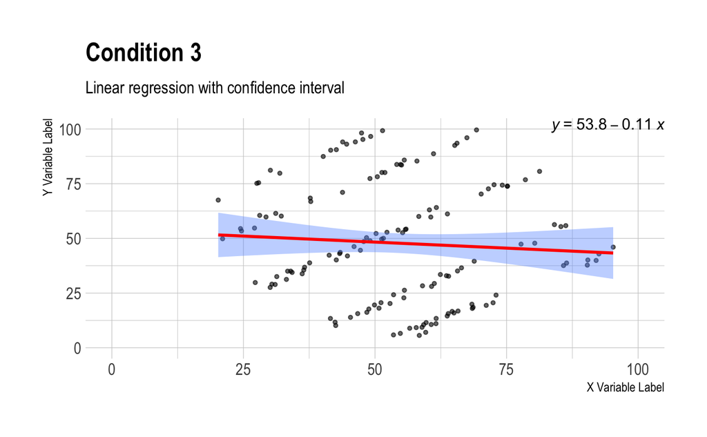

```r
condition3_plot <- ggplot(df_condition3, aes(x=x, y=y)) +
  geom_point(size=1, alpha=0.6) +
  geom_smooth(method=lm , color="red", fill="#6699ff", se=TRUE) +
    stat_poly_eq(aes(label = ..eq.label..),
    formula = y ~ x,
    label.x = max(df_condition3$x) * 0.5,
    label.y = max(df_condition3$y) * 0.9
  )+
  theme_ipsum() +
   labs(
    title = "Condition 3",
    subtitle = "Linear regression with confidence interval",
    x = "X Variable Label",
    y = "Y Variable Label"
    )+
  xlim(0,100)+ylim(0,100)
condition3_plot
```

## Condition 4

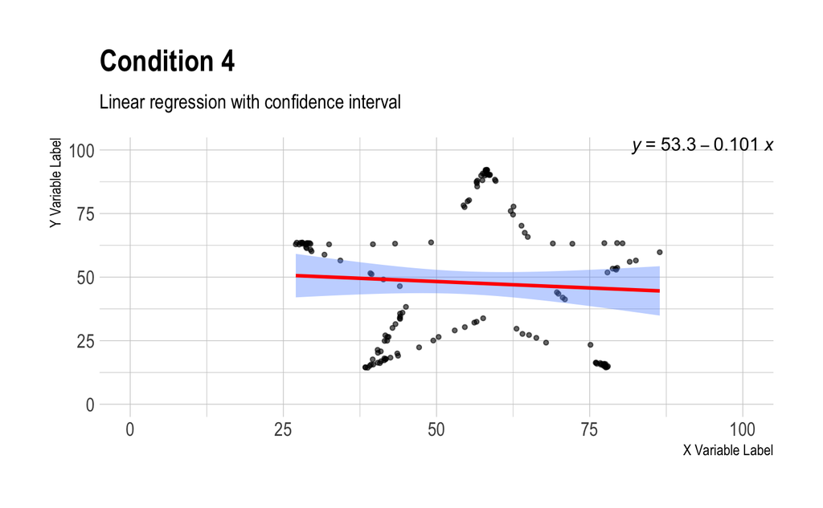

```r
condition4_plot <- ggplot(df_condition4, aes(x=x, y=y)) +
  geom_point(size=1, alpha=0.6) +
  geom_smooth(method=lm , color="red", fill="#6699ff", se=TRUE) +
    stat_poly_eq(aes(label = ..eq.label..),
    formula = y ~ x,
    label.x = max(df_condition4$x) * 0.5,
    label.y = max(df_condition4$y) * 0.9
  )+
  theme_ipsum() +
   labs(
    title = "Condition 4",
    subtitle = "Linear regression with confidence interval",
    x = "X Variable Label",
    y = "Y Variable Label"
    )+
  xlim(0,100)+ylim(0,100)
condition4_plot
```

# Reflection

**What can be concluded from the dataset?**

- Even though the summary statistics, regression, and correlation coefficients are very similar (or even exactly the same) across the four conditions, the data distributions could be very different
- And this dataset was probably created by someone artistic

**What did you find most challenging about this assignment?**

I found it surprisingly challenging to get R to isolate each condition and operate on each condition separately. Mostly because I didn’t know what kind of functions are available in R and what they do exactly. I first tried to convert the csv from long to wide, (and some other attempts I’ve forgotten) but then I couldn’t separate x and y when doing summary statistics. Eventually I figured out that i could define each condition as a separate dataframe and operate on them individually.

**What did you learn in completing this assignment? What are you still curious about?**

- Learned that R notebook is very powerful and fun
- And how to find coding help with the Internet (and that it’s okay to not know all they syntax of every language you use)
- Curious about how to deal with more complex types of data using R, beyond numeric values
- And maybe how the data analysis tools we have might limit our experimental design process
  - e.g. working with language, text, video, doing thematic analysis, etc.

**Why is it important to visualize data?**

- It’s a MUCH easier way to communicate and share the results compared to text, and helps widen the audience of your research
- Helps you inspect the shape and distribution of the data and detect any anomalous patterns or outliers
- It’s fun and it makes your report/paper more visually pleasing and readable :)